# Experiment Report for Shota

Author

Utku Turk

## 1 Filtering Steps

26.1% of the data is filtered out. Here’s the steps.

- After creating the transcription dictionary, preprocess them by removing the punctuations
- Filter out the utterances that does not end with *-ing*
- Filter out the utterances that does not start with *the*
- Find out what N2 are and filter out the utterances that have weird N2s
- There should be 7 words in every utterance, delete the ones that do not have exact 7 words
- Filter out the ones that contain the distractor verbs

```python
# process transcripts
def process_transc_dict(transc_dict):
    import string

    # Function to remove punctuation from a string
    def remove_punctuation(text):
        translator = str.maketrans("", "", string.punctuation)
        return text.translate(translator)

    # Remove punctuation from the value parts of transc_dict
    transc_dict_nopunct = {
        key: remove_punctuation(value).lower() for key, value in transc_dict.items()
    }

    return transc_dict_nopunct


transc_dict_nopunct = process_transc_dict(transc_dict)

# -ing ending
not_ing_end = {k: v for k, v in transc_dict_nopunct.items() if not v.endswith("ing")}
ing_end = {k: v for k, v in transc_dict_nopunct.items() if v.endswith("ing")}

# the start
not_the_start = {k: v for k, v in ing_end.items() if not v.split()[0] == "the"}
the_start = {k: v for k, v in ing_end.items() if v.split()[0] == "the"}

# weird N2s
weird_n2s = ["ball", "pink", "guitar", "pan"]

weird_n2 = {k: v for k, v in the_start.items() if v.split()[1] in weird_n2s}
no_weird_n2 = {k: v for k, v in the_start.items() if not v.split()[1] in weird_n2s}

# 7 words
correct_n = {k: v for k, v in no_weird_n2.items() if len(v.split()) == 7}
no_correct_n = {k: v for k, v in no_weird_n2.items() if len(v.split()) != 7}

# Distraction
not_distracted = {}
distracted = {}
for k, v in correct_n.items():
    to_check = k[:-9] + "_" + v.split()[6]
    for i in df_items["check"]:
        if to_check.startswith(i):
            distracted[k] = v
        else:
            not_distracted[k] = v
```

## 2 Get PCIbex Data and Trial No

```r
# libraries
library(tidyverse)
library(magrittr)
library(brms)
library(bayestestR)
# setwd(if (grepl("paper", getwd())) getwd() else "./report")
```

```r
# SETUP ----------------

workspace <- "../code/"
p <- \(x) paste0(workspace, x)
i <- \(x) paste0("ibex_results/shota_rep_", x)
cc <- \(x) paste0(x, ".csv")

source(p("0_scripts.R"))

file_names <- c("first_10", "prac", "till50", "till83")

invisible(list2env(
  lapply(
    setNames(cc(p(i(file_names))), file_names),
    read.pcibex
  ),
  envir = .GlobalEnv
))

get_trial_no <- function(data) {
  data |>
    filter(PennElementType == "MediaRecorder") |>
    filter(str_detect(Label, "^trial")) |>
    mutate(subject_id = str_sub(PennElementName, -4, -1)) |>
    select(filenames = PennElementName, Label, EventTime, subject_id) |>
    group_by(subject_id) |>
    mutate(trial_no = seq(subject_id)) |>
    ungroup()
}

get_name <- function(df, name) {
  df$type <- name
  df
}

invisible(list2env(lapply(mget(file_names), get_trial_no), .GlobalEnv))

invisible(list2env(Map(get_name, mget(file_names), file_names), envir = .GlobalEnv))

unique_subjects <- list()
for (name in file_names) {
  unique_subjects[[name]] <- unique(mget(file_names)[[name]]$subject_id)
}
all_subjects <- unlist(unique_subjects)
duplicates <- all_subjects[duplicated(all_subjects)]

stopifnot(length(duplicates) == 0)

invisible(list2env(lapply(mget(file_names), \(df) {
  df[] <- lapply(
    names(df),
    \(col) {
      if (col %in% c("filenames", "Label", "subject_id", "type")) {
        as.factor(df[[col]])
      } else {
        as.numeric(df[[col]])
      }
    }
  )
  df
}), envir = .GlobalEnv))


df <- bind_rows(mget(file_names), .id = "type")
write.csv(df, file = cc(p(i("merged_df"))))
```

There were 95 participants with 4560 total number of utterances, 48 trials for each participant.

## 3 Preprocess DF for Utterances

- Read the dataframe that consists of textgrid information
- Factorize necessary columns
- Convert seconds to miliseconds
- Encode information about the next and the previous words, such as the identity of the next/previous words, when they started (onset) and when they ended (offset)

Due to the server related issues, I have lost 0 subjects.

```r
fname <- p("merged_df_shota_rep.csv")
df <- read_csv(fname)


df <- df |> as.data.frame()
df <- df |> mutate(
  filenames = as.factor(filenames),
  exp = as.factor(exp),
  verb_type = as.factor(verb_type),
  dist_num = as.factor(dist_num),
  sem_type = as.factor(sem_type),
  subject_id = as.factor(subject_id),
  head = as.factor(head),
  start = start *  1000,
  end = end * 1000
)

# get important numbers, such as prev/next offset/onset,
grouped_laglead <- function(lag = 1, data, group, new_col, llag_col, default = NA) {
  if (lag) {
    data %>% group_by({{ group }}) %>%
      dplyr::mutate({{ new_col }} := lag({{ llag_col }}, n = 1, default = default))
  } else {
    data %>% group_by({{ group }}) %>%
      dplyr::mutate({{ new_col }} := lead({{ llag_col }}, n = 1, default = default))
  }
}

df %<>% grouped_laglead(lag = 0, ., filenames, next_word, response, default = NA)
df %<>% grouped_laglead(lag = 0, ., filenames, next_word_onset, start, default = NA)
df %<>% grouped_laglead(lag = 0, ., filenames, next_word_offset, end, default = NA)
df %<>% grouped_laglead(lag = 1, ., filenames, prev_word_onset, start, default = NA)
df %<>% grouped_laglead(lag = 1, ., filenames, prev_word_offset, end, default = NA)
df %<>% grouped_laglead(lag = 1, ., filenames, prev_word, response, default = NA)
```

## 4 Summary Stats

### 4.1 Onset Time

- The sentence onset means the time between the “*click*” sound and the onset of the first noun: *click* The octopus under the spoon is swimming.
- It seems like there might be an effect of verb type, but no interaction contra Momma and Ferreira (2019).

```r
onset <- df |>
  filter(is.na(prev_word)) |>
  filter(response == "the") |>
  as.data.frame()
# onset$duration <- onset$start
onset$duration <- onset$next_word_onset

ibex_df <- read_csv(cc(p(i("merged_df")))) |>
  as.data.frame() |>
  select(-...1)
full_onset <- merge(onset, ibex_df, by = c("filenames", "subject_id"))
```

```r
avg_fun <- function(data, measurevar = "duration", withinvars = c("verb_type", "sem_type"), idvar = "subject_id") {
  avgs <- Rmisc::summarySEwithin(data, measurevar = measurevar, withinvars = withinvars, idvar = idvar)
  # round a column if it is numeric
  avgs <- avgs |> mutate_if(is.numeric, round, 3)
  avgs$lower <- avgs[[measurevar]] - avgs$ci
  avgs$upper <- avgs[[measurevar]] + avgs$ci
  avgs
}

plot_fun <- function(df, pd = 0.1) {
  df |>
    ggplot(aes(verb_type, duration, linetype = sem_type, group = sem_type)) +
    geom_point(position = position_dodge(pd), size = 3) +
    geom_line(position = position_dodge(pd), linewidth = 1) +
    geom_errorbar(
      aes(ymin = duration-se, ymax = duration+se),
      width = 0.2, linewidth = 1, position = position_dodge(pd)
    ) +
    xlab("") +
    ylab("Onset Latency (ms)") +
    # scale_y_continuous(labels = scales::percent) +
    scale_x_discrete(
      name = "Verb Type",
      labels = c("Unacc" = "Unaccusative", "Unerg" = "Unergative")
    ) +
    scale_linetype_discrete(
      name = "Relatedness",
      labels = c("related" = "Related", "unrelated" = "Unrelated")
    ) +
    theme_classic() +
    # theme(text = element_text(size = 16, family = "Helvetica Neue")) +
    theme(
      strip.background = element_blank(),
      panel.grid.major.y = element_line(color = "darkgray", linetype = "dashed"),
      panel.grid.minor.y = element_line(color = "darkgray", linetype = "dashed")
    )
}


onset_avgs <- full_onset |> avg_fun()

onset_p_avgs <- onset_avgs |> plot_fun()
```

Table 1: The average **sentence onset** time for each condition, along with number of observations, its standard deviation, standard error, and credible interval.

[output not shown]

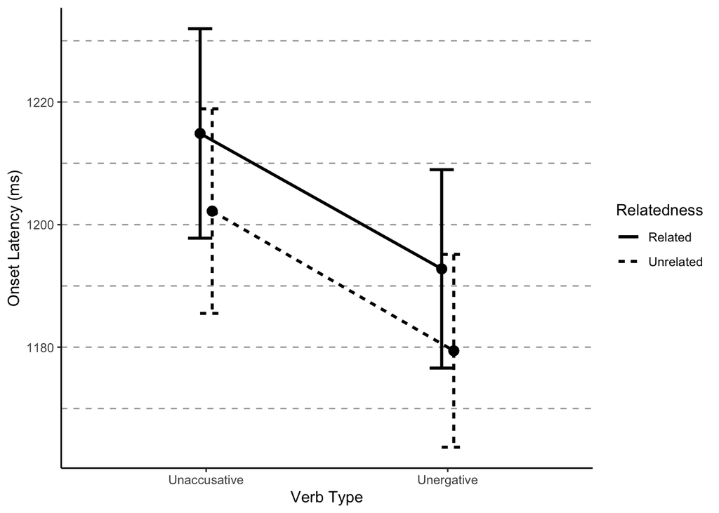

Figure 1: The average **onset** times according to the experimental conditions in our study. Error bars signal standard errors calculated following Morey (2008) and Cousineau (2005).